# R_TranTruongMinhThang

```r
library(tidyr)
library(tidyverse)

library(scales)
library(readxl)
library(openxlsx)
```

1. Đọc dữ liêu, hiên thi thông tin chung của dữ liêu : head(), tail(), str(), summary()

```r
house <- read.csv("ames_housing.csv")
```

```r
head(house)
```

|  | Id | PID | MS.SubClass | MS.Zoning | Lot.Frontage | Lot.Area | Street | Alley | Lot.Shape | Land.Contour | Utilities | Lot.Config | Land.Slope | Neighborhood | Condition.1 | Condition.2 | Bldg.Type | House.Style | Overall.Qual | Overall.Cond | Year.Built | Year.Remod.Add | Roof.Style | Roof.Matl | Exterior.1st | Exterior.2nd | Mas.Vnr.Type | Mas.Vnr.Area | Exter.Qual | … |
| --- | --- | --- | --- | --- | --- | --- | --- | --- | --- | --- | --- | --- | --- | --- | --- | --- | --- | --- | --- | --- | --- | --- | --- | --- | --- | --- | --- | --- | --- | --- |
| 1 | 109 | 533352170 | 60 | RL | NA | 13517 | Pave |  | IR1 | Lvl | AllPub | CulDSac | Gtl | Sawyer | RRAe | Norm | 1Fam | 2Story | 6 | 8 | 1976 | 2005 | Gable | CompShg | HdBoard | Plywood | BrkFace | 289 | Gd | … |
| 2 | 544 | 531379050 | 60 | RL | 43 | 11492 | Pave |  | IR1 | Lvl | AllPub | CulDSac | Gtl | SawyerW | Norm | Norm | 1Fam | 2Story | 7 | 5 | 1996 | 1997 | Gable | CompShg | VinylSd | VinylSd | BrkFace | 132 | Gd | … |
| 3 | 153 | 535304180 | 20 | RL | 68 | 7922 | Pave |  | Reg | Lvl | AllPub | Inside | Gtl | NAmes | Norm | Norm | 1Fam | 1Story | 5 | 7 | 1953 | 2007 | Gable | CompShg | VinylSd | VinylSd | None | 0 | TA | … |
| 4 | 318 | 916386060 | 60 | RL | 73 | 9802 | Pave |  | Reg | Lvl | AllPub | Inside | Gtl | Timber | Norm | Norm | 1Fam | 2Story | 5 | 5 | 2006 | 2007 | Gable | CompShg | VinylSd | VinylSd | None | 0 | TA | … |
| 5 | 255 | 906425045 | 50 | RL | 82 | 14235 | Pave |  | IR1 | Lvl | AllPub | Inside | Gtl | SawyerW | Norm | Norm | 1Fam | 1.5Fin | 6 | 8 | 1900 | 1993 | Gable | CompShg | Wd Sdng | Plywood | None | 0 | TA | … |
| 6 | 138 | 535126040 | 20 | RL | 137 | 16492 | Pave |  | IR1 | Lvl | AllPub | Corner | Gtl | NAmes | PosA | Norm | 1Fam | 1Story | 6 | 6 | 1966 | 2002 | Gable | CompShg | BrkFace | Plywood | None | 0 | Gd | … |

```r
tail(house)
```

|  | Id | PID | MS.SubClass | MS.Zoning | Lot.Frontage | Lot.Area | Street | Alley | Lot.Shape | Land.Contour | Utilities | Lot.Config | Land.Slope | Neighborhood | Condition.1 | Condition.2 | Bldg.Type | House.Style | Overall.Qual | Overall.Cond | Year.Built | Year.Remod.Add | Roof.Style | Roof.Matl | Exterior.1st | Exterior.2nd | Mas.Vnr.Type | Mas.Vnr.Area | Exter.Qual | … |
| --- | --- | --- | --- | --- | --- | --- | --- | --- | --- | --- | --- | --- | --- | --- | --- | --- | --- | --- | --- | --- | --- | --- | --- | --- | --- | --- | --- | --- | --- | --- |
| 2046 | 1051 | 528102030 | 20 | RL | 96 | 12444 | Pave |  | Reg | Lvl | AllPub | FR2 | Gtl | NridgHt | Norm | Norm | 1Fam | 1Story | 8 | 5 | 2008 | 2008 | Hip | CompShg | VinylSd | VinylSd | Stone | 426 | Ex | … |
| 2047 | 1587 | 921126030 | 20 | RL | 79 | 11449 | Pave |  | IR1 | HLS | AllPub | Inside | Gtl | Timber | Norm | Norm | 1Fam | 1Story | 8 | 5 | 2007 | 2007 | Gable | CompShg | VinylSd | VinylSd | None | 0 | Gd | … |
| 2048 | 785 | 905377130 | 30 | RL | NA | 12342 | Pave |  | IR1 | Lvl | AllPub | Inside | Gtl | Edwards | Norm | Norm | 1Fam | 1Story | 4 | 5 | 1940 | 1950 | Gable | CompShg | VinylSd | VinylSd | None | 0 | TA | … |
| 2049 | 916 | 909253010 | 50 | RL | 57 | 7558 | Pave |  | Reg | Bnk | AllPub | Inside | Gtl | Crawfor | Norm | Norm | 1Fam | 1.5Fin | 6 | 6 | 1928 | 1950 | Gable | CompShg | BrkFace | Stone | None | 0 | TA | … |
| 2050 | 639 | 535179160 | 20 | RL | 80 | 10400 | Pave |  | Reg | Lvl | AllPub | Corner | Gtl | NAmes | Norm | Norm | 1Fam | 1Story | 4 | 5 | 1956 | 1956 | Gable | CompShg | Plywood | Plywood | None | 0 | TA | … |
| 2051 | 10 | 527162130 | 60 | RL | 60 | 7500 | Pave |  | Reg | Lvl | AllPub | Inside | Gtl | Gilbert | Norm | Norm | 1Fam | 2Story | 7 | 5 | 1999 | 1999 | Gable | CompShg | VinylSd | VinylSd | None | 0 | TA | … |

```r
summary(house)
```

```
       Id              PID             MS.SubClass
 Min.   :   1.0   Min.   :526301100   Min.   : 20.00
 1st Qu.: 753.5   1st Qu.:528458140   1st Qu.: 20.00
 Median :1486.0   Median :535453200   Median : 50.00
 Mean   :1474.0   Mean   :713590006   Mean   : 57.01
 3rd Qu.:2198.0   3rd Qu.:907180080   3rd Qu.: 70.00
 Max.   :2930.0   Max.   :924152030   Max.   :190.00

  MS.Zoning          Lot.Frontage       Lot.Area
 Length:2051        Min.   : 21.00   Min.   :  1300
 Class :character   1st Qu.: 58.00   1st Qu.:  7500
 Mode  :character   Median : 68.00   Median :  9430
                    Mean   : 69.06   Mean   : 10065
                    3rd Qu.: 80.00   3rd Qu.: 11514
                    Max.   :313.00   Max.   :159000
                    NA's   :330
    Street             Alley            Lot.Shape
 Length:2051        Length:2051        Length:2051
 Class :character   Class :character   Class :character
 Mode  :character   Mode  :character   Mode  :character




 Land.Contour        Utilities          Lot.Config
 Length:2051        Length:2051        Length:2051
 Class :character   Class :character   Class :character
 Mode  :character   Mode  :character   Mode  :character




  Land.Slope        Neighborhood       Condition.1
 Length:2051        Length:2051        Length:2051
 Class :character   Class :character   Class :character
 Mode  :character   Mode  :character   Mode  :character




```

[output cut: 144 more lines]

```
   Pool.Area          Misc.Val           Mo.Sold
 Min.   :  0.000   Min.   :    0.00   Min.   : 1.00
 1st Qu.:  0.000   1st Qu.:    0.00   1st Qu.: 4.00
 Median :  0.000   Median :    0.00   Median : 6.00
 Mean   :  2.398   Mean   :   51.57   Mean   : 6.22
 3rd Qu.:  0.000   3rd Qu.:    0.00   3rd Qu.: 8.00
 Max.   :800.000   Max.   :17000.00   Max.   :12.00

    Yr.Sold      Sale.Type           SalePrice
 Min.   :2006   Length:2051        Min.   : 12789
 1st Qu.:2007   Class :character   1st Qu.:129825
 Median :2008   Mode  :character   Median :162500
 Mean   :2008                      Mean   :181470
 3rd Qu.:2009                      3rd Qu.:214000
 Max.   :2010                      Max.   :611657
```

2. Cho biết số dòng, số cột của dữ liệu

```r
# number of rows
nrow(house)
```

```
[1] 2051
```

```r
# number of columns
ncol(house)
```

```
[1] 76
```

3. Cho biết có bao nhiêu loại Garage.Type, đó là nhûng loai não, mỗi loại đếm được bao nhiêu mẫu.

```r
garage_type_counts <- house %>%
  group_by(Garage.Type) %>%
  summarise(count = n())

print(garage_type_counts)
```

| Garage.Type | count |
| --- | --- |
|  | 113 |
| 2Types | 19 |
| Attchd | 1213 |
| Basment | 27 |
| BuiltIn | 132 |
| CarPort | 11 |
| Detchd | 536 |

```r
cat("Number of types of Garage.Type:", length(garage_type_counts$Garage.Type), "\n")
```

```
Number of types of Garage.Type: 7
```

4. Xóa các cột Garage.Qual, Garage.Cond, Pool.QC, Fence, Misc.Feature trong dữ liêu

```r
house <- house %>%
  select(-c("Garage.Qual", "Garage.Cond", "Pool.QC", "Fence", "Misc.Feature"))
```

5. Tim max, min cúa Gr.Liv.Area the Electrical và Heating (sử dung group_by() và summarize()).

```r
result_5 <- house %>%
  group_by(Electrical, Heating) %>%
  summarize(
    max_area = max(Gr.Liv.Area, na.rm =T),
    min_area = min(Gr.Liv.Area, na.rm =T)
  )
```

6. Ve biểu đồ thể hiện mối liên hê cúa SalePrice và X1st.Fir.SF. Nhan xét biéu dò.

```r
library(ggplot2)
```

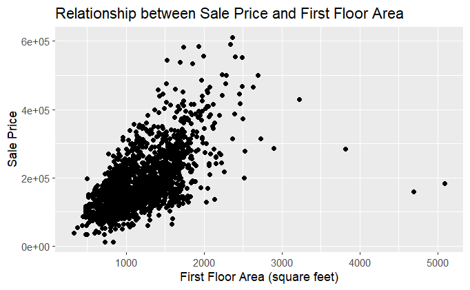

```r
ggplot(house, aes(x = X1st.Flr.SF, y = SalePrice)) +
  geom_point() +
  labs(x = "First Floor Area (square feet)", y = "Sale Price") +
  ggtitle("Relationship between Sale Price and First Floor Area")
```

Nhận xét: - Biểu đồ scatter plot trên thể hiện mối quan hệ giữa diện tích tầng trệt (“X1st.Fir.SF”) và giá bán (“SalePrice”) của các căn nhà - Giá trị của 2 biến này có tương quan thuận thể hiện diện tích càng tăng thì giá cũng tăng theo - rất hợp lý

7. Vẽ pie chart thể hiên % giữa Y(1) và N(0) cúa côt Central.Air

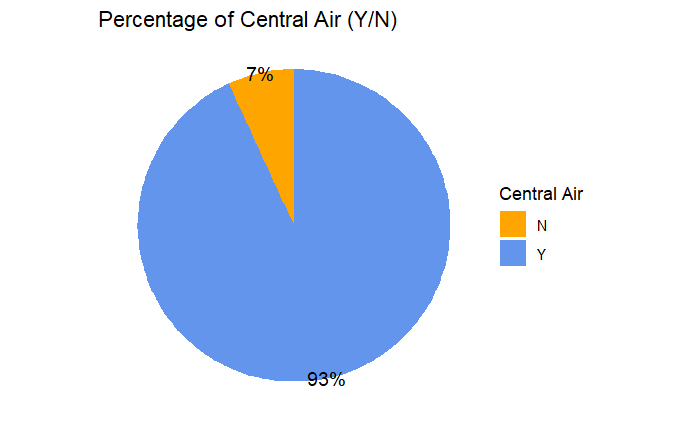

```r
# Calculate the percentage
percentage <- house %>%
  group_by(Central.Air) %>%
  summarize(count = n()) %>%
  mutate(percentage = count / sum(count) * 100)

# Create the pie chart
ggplot(percentage, aes(x = "", y = percentage, fill = Central.Air)) +
  geom_bar(stat = "identity", width = 1) +
  coord_polar("y", start = 0) +
  labs(fill = "Central Air", x = NULL, y = NULL, title = "Percentage of Central Air (Y/N)") +
  scale_fill_manual(values = c("#FFA500", "#6495ED")) +
  theme_void() +
  geom_text(aes(label = percent(percentage/100), x = 1.5), color = "black", size = 4, position = position_stack(vjust = 0.5)) +
  guides(fill = guide_legend(title = "Central Air"))
```

8. Cho biết năm xây cúa các căn nhà cũ nhất và mới nhất (theo Year.Built). Liêt kê các căn nhà cũ nhất và mới nhất vói 3 thông tin Id, Year.Built, SalePrice

```r
# Find the oldest and newest houses
oldest_house <- house %>%
  filter(Year.Built == min(Year.Built))

newest_house <- house %>%
  filter(Year.Built == max(Year.Built))

# Display the oldest house with desired columns
oldest_house_info <- oldest_house %>%
  select(Id, Year.Built, SalePrice)
print(oldest_house_info)
```

| Id | Year.Built | SalePrice |
| --- | --- | --- |
| 1319 | 1872 | 122000 |

```r
NA
```

```r
# Display the newest house with desired columns
newest_house_info <- newest_house %>%
  select(Id, Year.Built, SalePrice)
print(newest_house_info)
```

| Id | Year.Built | SalePrice |
| --- | --- | --- |
| 105 | 2010 | 267916 |

9. Thống kê số lượng các căn nhà được xây theo từng năm. In head và tail. Cho biêt năm nào có nhiều nhà được xây nhất?

```r
# Count the number of houses built each year
house_counts <- house %>%
  group_by(Year.Built) %>%
  summarize(count = n())
```

```r
# Print the head of the house counts
print(head(house_counts))
```

| Year.Built | count |
| --- | --- |
| 1872 | 1 |
| 1875 | 1 |
| 1879 | 1 |
| 1880 | 3 |
| 1885 | 1 |
| 1890 | 5 |

```r
# Print the tail of the house counts
print(tail(house_counts))
```

| Year.Built | count |
| --- | --- |
| 2005 | 102 |
| 2006 | 99 |
| 2007 | 78 |
| 2008 | 36 |
| 2009 | 14 |
| 2010 | 1 |

```r
# Find the year with the highest number of houses built
year_most_houses <- house_counts %>%
  filter(count == max(count))
print(year_most_houses)
```

| Year.Built | count |
| --- | --- |
| 2005 | 102 |

10. Trực quan hóa kết quá của câu thống kê trên với 10 năm gần đây nhất bäng barplot; với tất cả các năm bằng line.

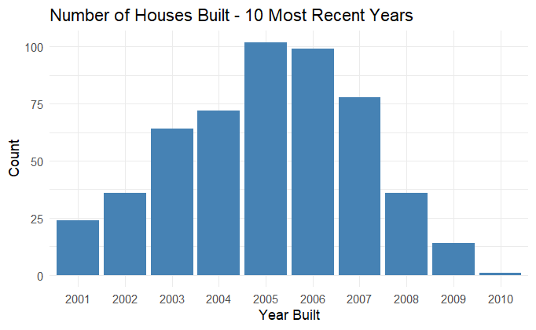

```r
# Filter for the 10 most recent years
recent_years <- house_counts %>%
  filter(Year.Built >= max(Year.Built) - 9)

# Create barplot for the 10 most recent years
ggplot(recent_years, aes(x = as.factor(Year.Built), y = count)) +
  geom_bar(stat = "identity", fill = "steelblue") +
  labs(title = "Number of Houses Built - 10 Most Recent Years",
       x = "Year Built",
       y = "Count") +
  theme_minimal()
```

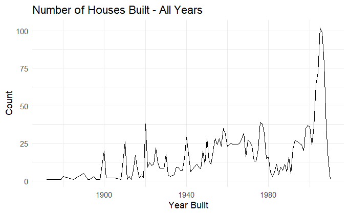

```r
# Create line plot for all years
ggplot(house_counts, aes(x = Year.Built, y = count)) +
  geom_line() +
  labs(title = "Number of Houses Built - All Years",
       x = "Year Built",
       y = "Count") +
  theme_minimal()
```

11. Vẽ boxplot của cột SalePrice

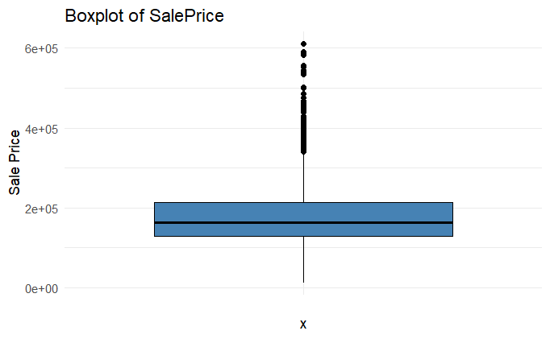

```r
# Create a boxplot of SalePrice
ggplot(house, aes(x = "", y = SalePrice)) +
  geom_boxplot(fill = "steelblue", color = "black") +
  labs(title = "Boxplot of SalePrice",
       y = "Sale Price") +
  theme_minimal()
```

1. đọc dữ liệu. Xem thông tin dữ liệu với head(), tail(), str(), summary().

```r
canxi <- read_excel("canxi.xlsx")
```

```r
# View the first few rows of the data
print(head(canxi))
```

| response_number | knowledge_score | calcium_intake |
| --- | --- | --- |
| 1 | 1.0 | 0.450 |
| 2 | 4.2 | 1.050 |
| 3 | 3.8 | 0.900 |
| 4 | 1.5 | 0.525 |
| 5 | 2.2 | 0.710 |
| 6 | 3.2 | 0.854 |

```r
# View the last few rows of the data
tail(canxi)
```

| response_number | knowledge_score | calcium_intake |
| --- | --- | --- |
| 15 | 2.2 | 0.583 |
| 16 | 4.5 | 0.850 |
| 17 | 1.8 | 0.798 |
| 18 | 2.4 | 0.754 |
| 19 | 3.0 | 0.805 |
| 20 | 4.3 | 1.085 |

```r
# View the structure of the data
str(canxi)
```

```
tibble [20 × 3] (S3: tbl_df/tbl/data.frame)
 $ response_number: num [1:20] 1 2 3 4 5 6 7 8 9 10 ...
 $ knowledge_score: num [1:20] 1 4.2 3.8 1.5 2.2 3.2 4 1.4 2.6 3.2 ...
 $ calcium_intake : num [1:20] 0.45 1.05 0.9 0.525 0.71 0.854 0.8 0.493 0.73 0.894 ...
```

```r
# View summary statistics of the data
summary(canxi)
```

```
 response_number knowledge_score calcium_intake
 Min.   : 1.00   Min.   :1.00    Min.   :0.4500
 1st Qu.: 5.75   1st Qu.:2.20    1st Qu.:0.7250
 Median :10.50   Median :2.90    Median :0.7990
 Mean   :10.50   Mean   :2.96    Mean   :0.7851
 3rd Qu.:15.25   3rd Qu.:3.85    3rd Qu.:0.8955
 Max.   :20.00   Max.   :4.80    Max.   :1.0850
```

2. vẽ biểu đồ phân phối tần xuất của knowledge_score. Nhân xét.

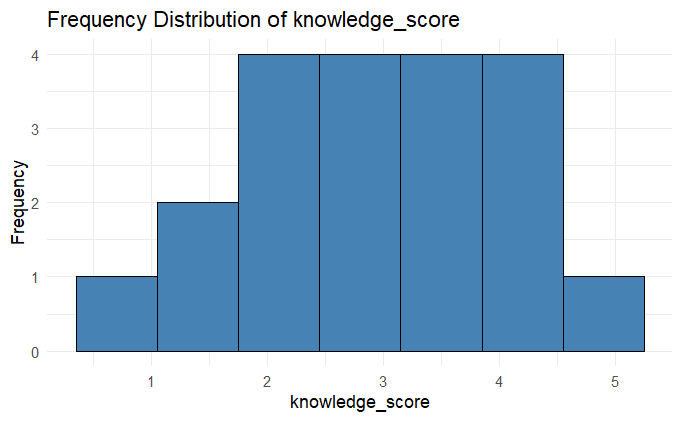

```r
# Create a frequency distribution plot of knowledge_score
ggplot(canxi, aes(x = knowledge_score)) +
  geom_histogram(binwidth = 0.7, fill = "steelblue", color = "black") +
  labs(title = "Frequency Distribution of knowledge_score",
       x = "knowledge_score",
       y = "Frequency") +
  theme_minimal()
```

Nhận xét: nhìn qua theo bin = 0.7 thì biểu đồ có normal distribution- tuy nhiên dữ liệu quá ít chỉ 20 records, nên khó có thể đưa ra kết luận

Tạo bảng đếm tần xuất:

```r
frequency_knowledge_score <- table(canxi$knowledge_score)
print(frequency_knowledge_score)
```

```
  1 1.4 1.5 1.8 2.2 2.4 2.5 2.6 2.8   3 3.2 3.8   4 4.2 4.3 4.5
  1   1   1   1   2   1   1   1   1   1   2   2   1   1   1   1
4.8
  1
```

ta có thể thấy chỉ có 3 giá trị 2.2, 3.2, 3.8 là xuất hiện 2 lần, còn lại mọi thứ đều xuất hiện 1 lần - nó rất giống uniform distribution

Ta sẽ vẽ lại histogram theo bin = 0.1

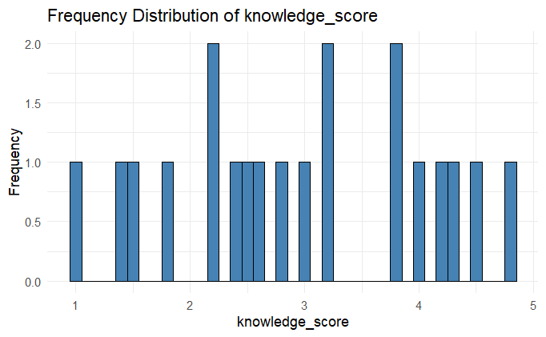

```r
# Create a frequency distribution plot of knowledge_score
ggplot(canxi, aes(x = knowledge_score)) +
  geom_histogram(binwidth = 0.1, fill = "steelblue", color = "black") +
  labs(title = "Frequency Distribution of knowledge_score",
       x = "knowledge_score",
       y = "Frequency") +
  theme_minimal()
```

Vì dữ liệu khá ít nên khó có thể kết luận, nhưng nhìn chung là normal distribution

3. Thực hiên các thống kê cơ bản cho knowledge_score và calcium_intake (mean, median, max, min)

```r
knowledge_mean <- mean(canxi$knowledge_score)
knowledge_median <- median(canxi$knowledge_score)
knowledge_max <- max(canxi$knowledge_score)
knowledge_min <- min(canxi$knowledge_score)
```

```r
calcium_mean <- mean(canxi$calcium_intake)
calcium_median <- median(canxi$calcium_intake)
calcium_max <- max(canxi$calcium_intake)
calcium_min <- min(canxi$calcium_intake)
cat("Statistics for calcium_intake:\n")
```

```
Statistics for calcium_intake:
```

```r
cat("Mean:", calcium_mean, "\n")
```

```
Mean: 0.7851
```

```r
cat("Median:", calcium_median, "\n")
```

```
Median: 0.799
```

```r
cat("Maximum:", calcium_max, "\n")
```

```
Maximum: 1.085
```

```r
cat("Minimum:", calcium_min, "\n")
```

```
Minimum: 0.45
```

4. Vë boxplot cho knowledge_score và cho calcium_intake. knowledge_score có outlier hay không? calcium intake co outlier hay không? Nhận xét

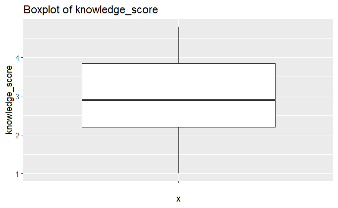

```r
# Boxplot for knowledge_score
ggplot(canxi, aes(x = "", y = knowledge_score)) +
  geom_boxplot() +
  labs(title = "Boxplot of knowledge_score")
```

-> knowledge_score: không có outlier

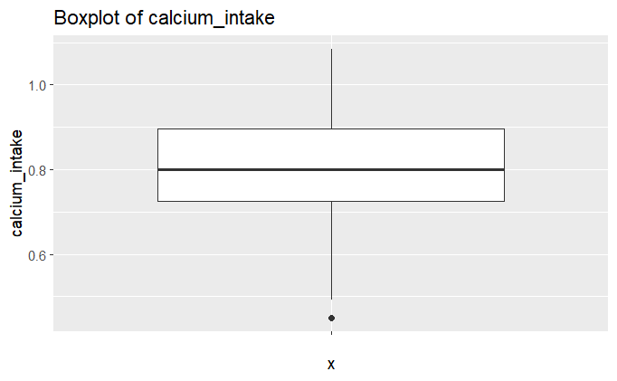

```r
# Boxplot for calcium_intake
ggplot(canxi, aes(x = "", y = calcium_intake)) +
  geom_boxplot() +
  labs(title = "Boxplot of calcium_intake")
```

-> calcium_intake có outlier - nhỏ hơn 0.6 -> cả 2 biểu đồ ta thấy: + boxplot khá gọn và đối xứng, điều này cho thấy một phân phối tương đối đồng đều + Độ lệch: đường ngang trong hộp (box) nằm hơi lệch xuống dưới một chút, điều này cho thấy sự lệch phân phối các phía giá trị nhỏ hơn. Điều này có thể chỉ ra rằng có một phần dữ liệu có xu hướng tập trung ở các giá trị thấp hơn

1. Đọc dữ liệu. Xem thông tin dữ liệu với head(), tail(), str(), summary().

```r
fruit <- read.table("fruit_data_with_colors.txt", header = TRUE, sep = "\t")
```

```r
# View the first few rows of the data
head(fruit)
```

|  | fruit_label | fruit_name | fruit_subtype | mass | width | height | color_score |
| --- | --- | --- | --- | --- | --- | --- | --- |
| 1 | 1 | apple | granny_smith | 192 | 8.4 | 7.3 | 0.55 |
| 2 | 1 | apple | granny_smith | 180 | 8.0 | 6.8 | 0.59 |
| 3 | 1 | apple | granny_smith | 176 | 7.4 | 7.2 | 0.60 |
| 4 | 2 | mandarin | mandarin | 86 | 6.2 | 4.7 | 0.80 |
| 5 | 2 | mandarin | mandarin | 84 | 6.0 | 4.6 | 0.79 |
| 6 | 2 | mandarin | mandarin | 80 | 5.8 | 4.3 | 0.77 |

```r
# View the last few rows of the data
tail(fruit)
```

|  | fruit_label | fruit_name | fruit_subtype | mass | width | height | color_score |
| --- | --- | --- | --- | --- | --- | --- | --- |
| 54 | 4 | lemon | unknown | 120 | 6.0 | 8.4 | 0.74 |
| 55 | 4 | lemon | unknown | 116 | 6.1 | 8.5 | 0.71 |
| 56 | 4 | lemon | unknown | 116 | 6.3 | 7.7 | 0.72 |
| 57 | 4 | lemon | unknown | 116 | 5.9 | 8.1 | 0.73 |
| 58 | 4 | lemon | unknown | 152 | 6.5 | 8.5 | 0.72 |
| 59 | 4 | lemon | unknown | 118 | 6.1 | 8.1 | 0.70 |

```r
# Inspect the structure of the data
str(fruit)
```

```
'data.frame':   59 obs. of  7 variables:
 $ fruit_label  : int  1 1 1 2 2 2 2 2 1 1 ...
 $ fruit_name   : chr  "apple" "apple" "apple" "mandarin" ...
 $ fruit_subtype: chr  "granny_smith" "granny_smith" "granny_smith" "mandarin" ...
 $ mass         : num  192 180 176 86 84 80 80 76 178 172 ...
 $ width        : num  8.4 8 7.4 6.2 6 5.8 5.9 5.8 7.1 7.4 ...
 $ height       : num  7.3 6.8 7.2 4.7 4.6 4.3 4.3 4 7.8 7 ...
 $ color_score  : num  0.55 0.59 0.6 0.8 0.79 0.77 0.81 0.81 0.92 0.89 ...
```

```r
# Summarize the data
summary(fruit)
```

```
  fruit_label     fruit_name        fruit_subtype
 Min.   :1.000   Length:59          Length:59
 1st Qu.:1.000   Class :character   Class :character
 Median :3.000   Mode  :character   Mode  :character
 Mean   :2.542
 3rd Qu.:4.000
 Max.   :4.000
      mass           width           height
 Min.   : 76.0   Min.   :5.800   Min.   : 4.000
 1st Qu.:140.0   1st Qu.:6.600   1st Qu.: 7.200
 Median :158.0   Median :7.200   Median : 7.600
 Mean   :163.1   Mean   :7.105   Mean   : 7.693
 3rd Qu.:177.0   3rd Qu.:7.500   3rd Qu.: 8.200
 Max.   :362.0   Max.   :9.600   Max.   :10.500
  color_score
 Min.   :0.5500
 1st Qu.:0.7200
 Median :0.7500
 Mean   :0.7629
 3rd Qu.:0.8100
 Max.   :0.9300
```

2. Hãy cho biết kiểu dữ liệu của cột fruit_name và fruit_subtype. Nếu kiểu dữ liệu không phải là factor thì hãy chuyển thành factor

```r
# Check the data type of the fruit_name column
class(fruit$fruit_name)
```

```
[1] "character"
```

```r
fruit$fruit_name <- as.factor(fruit$fruit_name)
```

```r
# Check the data type of the fruit_subtype column
class(fruit$fruit_subtype)
```

```
[1] "character"
```

```r
fruit$fruit_subtype <- as.factor(fruit$fruit_subtype)
```

3. Có bao nhiêu loai fruit_name? Đó là những loại nào? Có bao nhiêu loai fruit_subtype? Đó là những loại nào?

```r
# Number of fruit_name types
num_fruit_names <- length(unique(fruit$fruit_name))
cat("Number of fruit_name:", num_fruit_names, "\n")
```

```
Number of fruit_name: 4
```

```r
# List of fruit_name types
fruit_names <- levels(fruit$fruit_name)
cat("Fruit_name:", fruit_names)
```

```
Fruit_name: apple lemon mandarin orange
```

```r
# Number of fruit_subtype types
num_fruit_subtypes <- length(unique(fruit$fruit_subtype))
cat("Number of fruit_subtypes:", num_fruit_subtypes, "\n")
```

```
Number of fruit_subtypes: 10
```

```r
# List of fruit_subtypes types
fruit_subtypes <- levels(fruit$fruit_subtype)
cat("Fruit_subtype:", fruit_subtypes)
```

```
Fruit_subtype: braeburn cripps_pink golden_delicious granny_smith mandarin selected_seconds spanish_belsan spanish_jumbo turkey_navel unknown
```

4. Hãy lọc ra tất cả các dòng dữ liệu có fruit_name là ’apple’chứa vào dataframe df_apple. hãy cho biết có bao nhiêu dòng dữ liệu thoả điều kiên này?

```r
# Filter the data where fruit_name is 'apple' into the df_apple dataframe
df_apple <- subset(fruit, fruit_name == 'apple')

# Check the number of rows that satisfy the condition
apple_rows <- nrow(df_apple)
print(apple_rows)
```

```
[1] 19
```

5. Hãy lưu dataframe df_apple vão tâp tin apple.csv

```r
write.csv(df_apple, file = "apple.csv", row.names = FALSE)
```

6. Hãy lọc ra tất cả các dữ liệu có fruit_subtype là ‘golden_delicious’ chứa vào dataframe df_golden_delicious. hãy cho biết có bao nhiêu dòng dữ liệu thoả điều kiên này?

```r
df_golden_delicious <- subset(fruit, fruit_subtype == 'golden_delicious')
```

```r
golden_delicious_rows <- nrow(df_golden_delicious)
print(golden_delicious_rows)
```

```
[1] 5
```

7. Hãy lưu dataframe df_golden_delicious vão tâp tin golden_delicious.xlsx

```r
# Install openxlsx package if not already installed
# install.packages("openxlsx")
```

```r
write.xlsx(df_golden_delicious, file = "golden_delicious.xlsx", rowNames = FALSE)
```

8. Hãy lưu dataframe df_golden_delicious väo tâp tin golden_delicious.xml

Không làm đc thậy ạ :(

```r
library(xml2)
```

```r
# Convert the dataframe to XML format
xml_data <- xml2::as_xml_document(list(df_golden_delicious))

# Save the XML data to the 'golden_delicious.xml' file
write_xml(xml_data, file = "golden_delicious.xml")
```

9. Nhóm theo fruit_subtype, hãy thống kê số lượng mẫu theo từng subtype; max và min từng cột mass, width, height. (Gợi ý: dung group_by() và summarize())

```r
summary_fruit_subtype <- fruit %>%
  group_by(fruit_subtype) %>%
  summarize(count = n(),
            max_mass = max(mass),
            min_mass = min(mass),
            max_width = max(width),
            min_width = min(width),
            max_height = max(height),
            min_height = min(height))

print(summary_fruit_subtype)
```

| fruit_subtype | count | max_mass | min_mass | max_width | min_width | max_height | min_height |
| --- | --- | --- | --- | --- | --- | --- | --- |
| braeburn | 5 | 178 | 154 | 7.4 | 6.9 | 7.8 | 7.0 |
| cripps_pink | 6 | 170 | 140 | 7.6 | 7.3 | 7.9 | 7.1 |
| golden_delicious | 5 | 168 | 152 | 7.7 | 7.3 | 7.7 | 7.1 |
| granny_smith | 3 | 192 | 176 | 8.4 | 7.4 | 7.3 | 6.8 |
| mandarin | 5 | 86 | 76 | 6.2 | 5.8 | 4.7 | 4.0 |
| selected_seconds | 6 | 210 | 140 | 7.8 | 6.7 | 9.2 | 7.0 |
| spanish_belsan | 6 | 216 | 174 | 7.3 | 7.2 | 10.5 | 9.2 |
| spanish_jumbo | 3 | 362 | 342 | 9.6 | 9.0 | 9.4 | 9.2 |
| turkey_navel | 10 | 190 | 142 | 7.6 | 6.8 | 8.2 | 7.2 |
| unknown | 10 | 152 | 116 | 6.5 | 5.8 | 8.7 | 7.5 |

10. Häy lưu kết quả thông kê trên vào file subtype_summarize.json

```r
# Install jsonlite package if not already installed
# install.packages("jsonlite")
```

```r
library(jsonlite)
```

```r
# Convert the summary data to JSON format
json_data <- toJSON(summary_fruit_subtype, pretty = TRUE)

# Save the JSON data to the 'subtype_summarize.json' file
write(json_data, file = "subtype_summarize.json")
```

10. Đọc file subtype_summarize.json vừa lưu. In nội dung

```r
# Read the JSON data from the 'subtype_summarize.json' file
json_data_read <- readLines("subtype_summarize.json")

# Print the contents of the JSON data
print(json_data)
```

```
[
  {
    "fruit_subtype": "braeburn",
    "count": 5,
    "max_mass": 178,
    "min_mass": 154,
    "max_width": 7.4,
    "min_width": 6.9,
    "max_height": 7.8,
    "min_height": 7
  },
  {
    "fruit_subtype": "cripps_pink",
    "count": 6,
    "max_mass": 170,
    "min_mass": 140,
    "max_width": 7.6,
    "min_width": 7.3,
    "max_height": 7.9,
    "min_height": 7.1
  },
  {
    "fruit_subtype": "golden_delicious",
    "count": 5,
    "max_mass": 168,
    "min_mass": 152,
    "max_width": 7.7,
    "min_width": 7.3,
    "max_height": 7.7,
    "min_height": 7.1
  },
  {
    "fruit_subtype": "granny_smith",
    "count": 3,
    "max_mass": 192,
    "min_mass": 176,
    "max_width": 8.4,
    "min_width": 7.4,
    "max_height": 7.3,
    "min_height": 6.8
```

[output cut: 47 more lines]

```
    "min_width": 6.8,
    "max_height": 8.2,
    "min_height": 7.2
  },
  {
    "fruit_subtype": "unknown",
    "count": 10,
    "max_mass": 152,
    "min_mass": 116,
    "max_width": 6.5,
    "min_width": 5.8,
    "max_height": 8.7,
    "min_height": 7.5
  }
]
```